# Determinants of Maritime Piracy

Bjoern Boening, Laurence Hendry & Cody Koebnick

4 December 2015

# Contents

- Introduction & Contents
  - Maritime Piracy: Our Data for this 21st Century Problem
- Laurence
  - Global Overview: Piracy and Maritime Defence Propensity
  - Regional Focus: Piracy in the South China Sea
  - Regional Focus: Piracy in the Gulf of Aden & Arabian Sea
- Cody
  - Aggregated Data: The 8 Countries with Highest Amounts of Piracy
  - Adding Variables: Military Expenditure and Military Conflicts
  - Regression Results
- Bjoern
  - Model
  - Model & Chi Square Test
  - Innocent Logistic Model
  - Scrutinise Us

# Global Overview: Piracy and Maritime Defence Propensity

```
## [1] "V1" "V7"
```

[interactive chart not shown]

- Country borders highlighted green; Philippines highlighted red; Arc length indicates height of coast-to-country ratio (small to large)
- *H1: Most pirate attacks occur in areas where countries have smaller country-to-coast ratios, and thus are less incentivised to defend against maritime pirate attacks.*
- H0: Whether a country has a greater country-to-coast ratio has either an inverse or no effect on where pirate attacks occur.
- This is not always the case, depending on region. Our H1 remains true for the area around the Gulf of Aden and particularly in the Arabian Sea, but not for the South China Sea.
- 3D Globes using the ‘threejs’ Package: The 3D Globe package

# Regional Focus: Piracy in the South China Sea

[interactive chart not shown]

- Country borders highlighted green; Indonesia highlighted red; Arc length indicates vessel status (moving to stationary)
- *H1: Stationary ships are more likely to be attacked than moving ships in Southeast Asia.*
- H0: Stationary ships are no less, or less likely, to be attacked than moving ships in Southeast Asia.
- We can observe that whether a ship was moving (dot) or stationary (arc) appears to make little difference to the number of relative pirate attacks.

# Regional Focus: Piracy in the Gulf of Aden & Arabian Sea

[interactive chart not shown]

- Country borders highlighted green; Somalia highlighted red; Arc length indicates vessel status (stationary to moving)
- *H1: Stationary ships are more likely to be attacked than moving ships in the Arabian Sea.*
- H0: Stationary ships are no less, or less likely, to be attacked than moving ships in the Arabian Sea.
- We can observe that whether a ship was moving (dot) or stationary (arc) appears to make a large difference to the number of relative pirate attacks. Ships that were underway were more likely to be attacked.

# Aggregated Data: The 8 Countries with Highest Amounts of Piracy

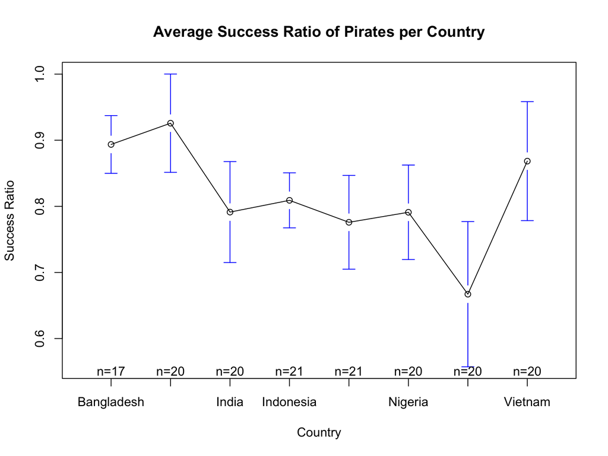

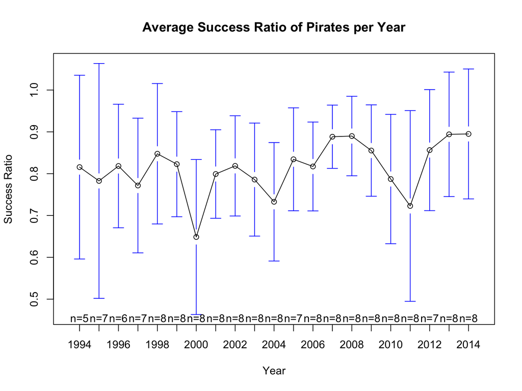

# Adding Variables: Military Expenditure and Military Conflicts

```
## [1] "/Users/laurencehendry/GitHub/MaritimePiracy/Presentation"
```

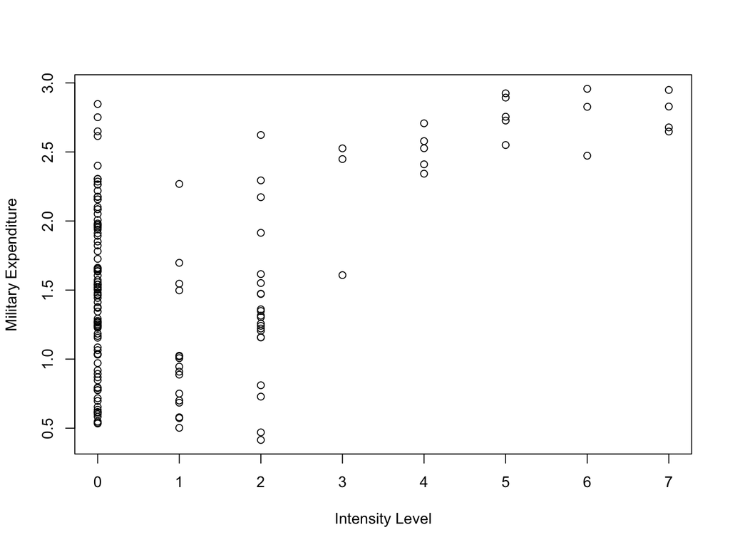

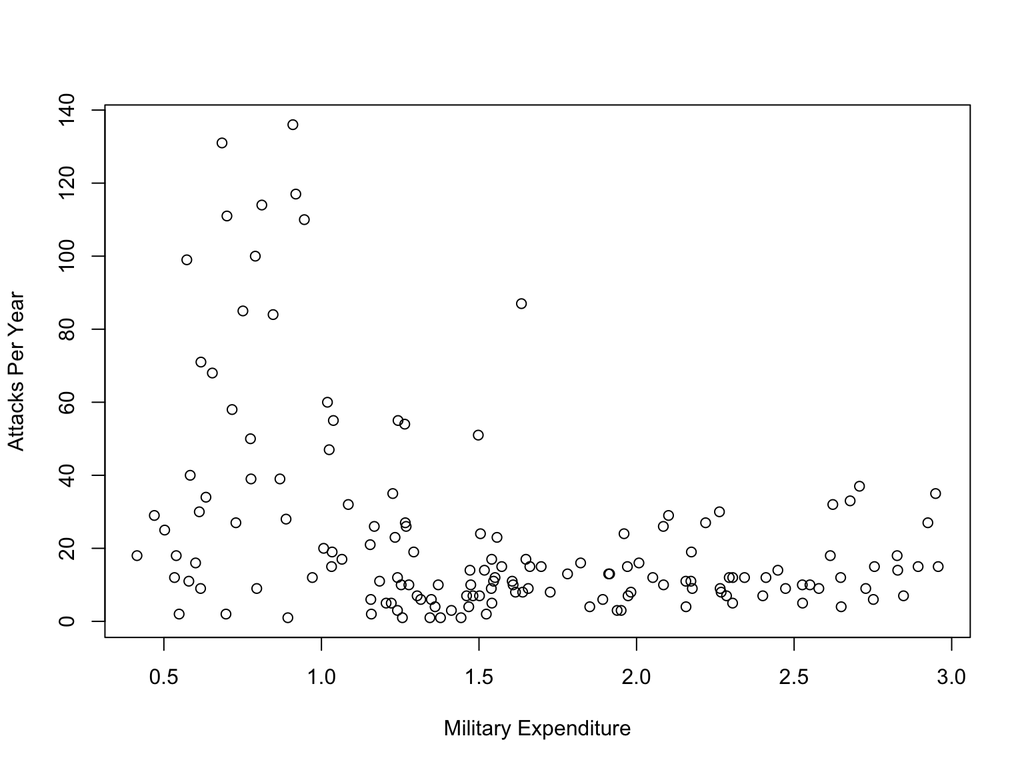

# Regression Results

Fitting linear model: ship.ucdp.mil$`attacks/Year` ~ ship.ucdp.mil$`coast/Area ratio (m/km2)` + ship.ucdp.mil$`GDP per cap` + ship.ucdp.mil$`Military Expenditure`

|  | Estimate | Std. Error | t value | Pr(>\|t\|) |
| --- | --- | --- | --- | --- |
| **ship.ucdp.mil$`coast/Area ratio (m/km2)`** | -0.05536 | 0.05365 | -1.032 | 0.3039 |
| **ship.ucdp.mil$`GDP per cap`** | -5.782e-05 | 0.0004107 | -0.1408 | 0.8883 |
| **ship.ucdp.mil$`Military Expenditure`** | -15.32 | 3.077 | -4.979 | 1.753e-06 |
| **(Intercept)** | 49.34 | 6.094 | 8.097 | 1.907e-13 |

```
## Oneway (individual) effect Within Model
##
## Call:
## plm(formula = ship.ucdp.mil$`attacks/Year` ~ ship.ucdp.mil$`Military Expenditure` +
##     ship.ucdp.mil$`GDP per cap`, data = ship.ucdp.mil, model = "within",
##     index = c("country", "year"))
##
## Unbalanced Panel: n=8, T=13-21, N=152
##
## Residuals :
##    Min. 1st Qu.  Median 3rd Qu.    Max.
##  -48.70   -7.61   -1.47    5.62   59.30
##
## Coefficients :
##                                         Estimate  Std. Error t-value
## ship.ucdp.mil$`Military Expenditure` -1.0257e+01  5.9010e+00 -1.7382
## ship.ucdp.mil$`GDP per cap`          -8.9853e-04  6.9308e-04 -1.2964
##                                      Pr(>|t|)
## ship.ucdp.mil$`Military Expenditure`  0.08434 .
## ship.ucdp.mil$`GDP per cap`           0.19693
## ---
## Signif. codes:  0 '***' 0.001 '**' 0.01 '*' 0.05 '.' 0.1 ' ' 1
##
## Total Sum of Squares:    38687
## Residual Sum of Squares: 37840
## R-Squared      :  0.021897
##       Adj. R-Squared :  0.020456
## F-statistic: 1.58947 on 2 and 142 DF, p-value: 0.20764
```

# Model

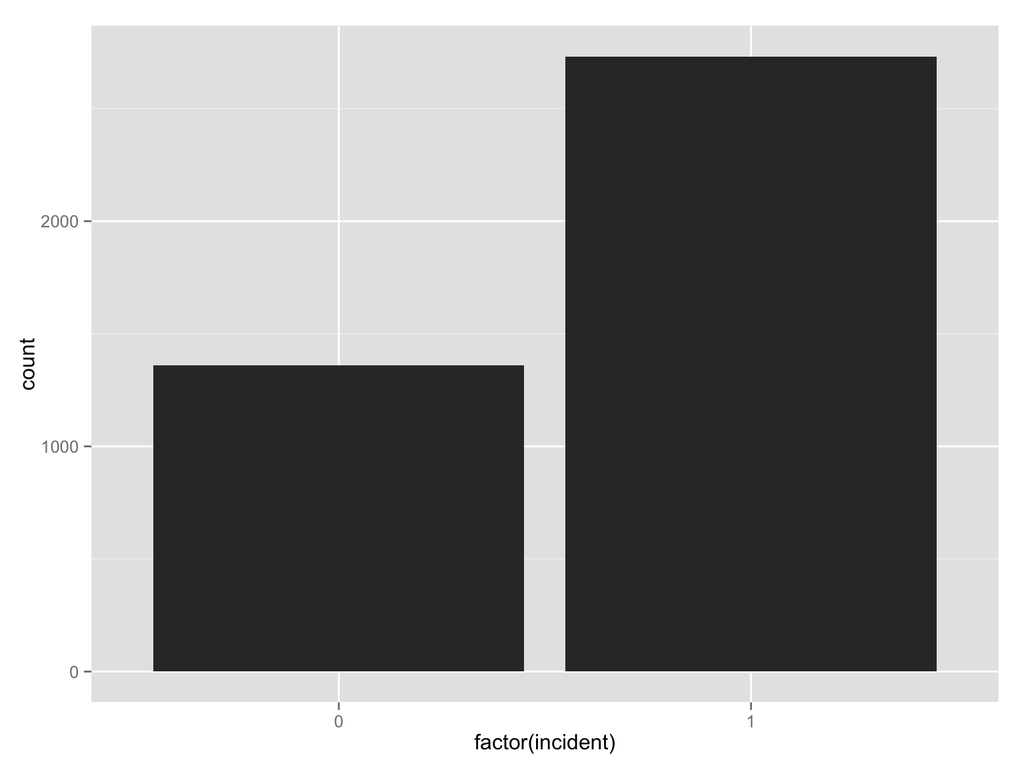

# Model & Chi Square Test

- H1. The success rate of an attacks shrinks for big ships,
- H2. And for vessels in motion,
- H3. And during the day.

### Ship Type

```
## Number of cases in table: 4091
## Number of factors: 2
## Test for independence of all factors:
##  Chisq = 33.24, df = 1, p-value = 8.14e-09
```

### Ship status (Factor)

```
## Number of cases in table: 4091
## Number of factors: 2
## Test for independence of all factors:
##  Chisq = 914.4, df = 1, p-value = 7.342e-201
```

### Time of day (Factor)

```
## Number of cases in table: 4091
## Number of factors: 2
## Test for independence of all factors:
##  Chisq = 286.95, df = 3, p-value = 6.638e-62
```

# Innocent Logistic Model

**Regression Results**

|  | *Dependent variable:* |
| --- | --- |
|  | incident |
| type2 | 0.91*** |
|  | (0.11) |
| Constant | 0.77*** |
|  | (0.03) |
| Observations | 5,648 |
| Log Likelihood | -3,408.18 |
| Akaike Inf. Crit. | 6,820.37 |
| *Note:* | p<0.1; p<0.05; p<0.01 |

# Srutinize us

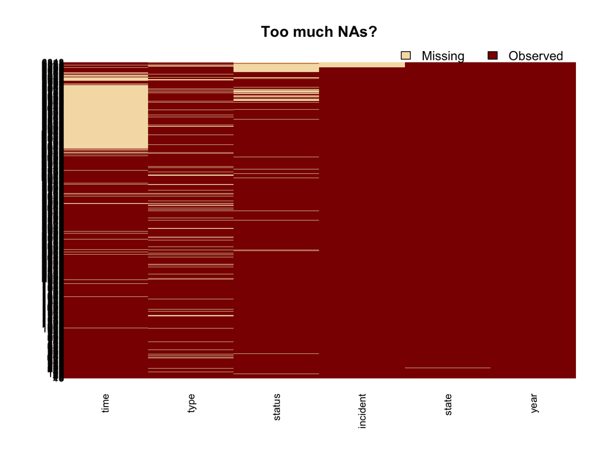